# team_04.qmd

Author

Ashsyahid, Owen, Sherwyn, Xuan Yu, Nigel

# 1. Data Preprocessing

## 1.1 Exploratory Data Analysis

### 1.1.1 Load data and assign to dataframe

We can use the `head()` method to inspect the first few rows of the dataframe.

```r
# Open the NetCDF file
ncfile <- nc_open("data/gistemp1200_GHCNv4_ERSSTv5.nc")

# Extract variables
lat <- ncvar_get(ncfile, "lat")
lon <- ncvar_get(ncfile, "lon")
time <- ncvar_get(ncfile, "time")
anomaly <- ncvar_get(ncfile, "tempanomaly")

# Extract attributes
scale_factor <- ncatt_get(ncfile, "tempanomaly", "scale_factor")$value
fill_value <- ncatt_get(ncfile, "tempanomaly", "_FillValue")$value

# Convert time variable to date
time_units <- ncatt_get(ncfile, "time", "units")$value
origin <- as.Date(sub("days since ", "", time_units))
date <- origin + time

# Apply scale factor and handle missing values
anomaly <- ifelse(anomaly == fill_value, NA, anomaly) * (scale_factor * 10)

# Reshape the data into a long format dataframe
df <- expand.grid(lon = lon, lat = lat, time = date)
df$anomaly <- as.vector(anomaly)

# UNCOMMENT THE CHUNK BELOW WHEN NECESSARY
# df$geographical_zone <- mapply(categorize_location, df$lat, df$lon)

# Close the NetCDF file
nc_close(ncfile)

# Display the first few rows of the dataframe
head(df)
```

```
   lon lat       time anomaly
1 -179 -89 1880-01-15      NA
2 -177 -89 1880-01-15      NA
3 -175 -89 1880-01-15      NA
4 -173 -89 1880-01-15      NA
5 -171 -89 1880-01-15      NA
6 -169 -89 1880-01-15      NA
```

### 1.1.2 Slice data

```r
# Filter the data for years 1960 to 2024
df <- df[df$time >= as.Date("1960-01-01") & df$time <= as.Date("2024-12-31"), ]
```

### 1.1.3 Missing values

Here, we can see that the original `dataframe` consists of `115935` missing values in the `anomaly` column. To visualize our missing data, we will plot a matrix chart of missing values by time. For efficiency sake, we will first sample the data before visualizing the missing data

```r
# Count the number of NA values for each column
na_count <- colSums(is.na(df))
na_count
```

```
    lon     lat    time anomaly
      0       0       0  115935
```

### 1.1.4 Sample Data for faster EDA

Data is sampled to **speed up** initial exploration of dataset. Random sampling is used to sample 1% of the dataset.

```r
set.seed(42)
sample_df <- df %>% sample_frac(0.01)

summary(sample_df)
```

```
      lon                 lat                time               anomaly
 Min.   :-179.0000   Min.   :-89.0000   Min.   :1960-01-15   Min.   :-1.0900
 1st Qu.: -89.0000   1st Qu.:-45.0000   1st Qu.:1976-03-15   1st Qu.:-0.0220
 Median :   1.0000   Median :  1.0000   Median :1992-03-15   Median : 0.0310
 Mean   :   0.3969   Mean   :  0.1828   Mean   :1992-03-22   Mean   : 0.0424
 3rd Qu.:  91.0000   3rd Qu.: 45.0000   3rd Qu.:2008-03-15   3rd Qu.: 0.0920
 Max.   : 179.0000   Max.   : 89.0000   Max.   :2024-06-15   Max.   : 1.4150
                                                             NA's   :1081
```

### 1.1.5 Pattern of missing values

We use a matrix chart to visualize the pattern of missing values by time. This will help us understand if there are any specific time periods with more missing values. Additionally, it can provide us information on the *type of missingness* in the dataset.

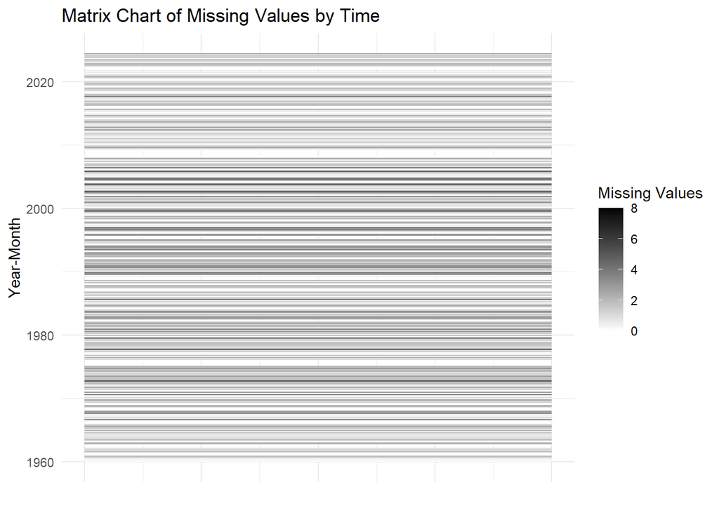

```r
# Extract year and month from the time column
format_sample_df <- sample_df %>%
  mutate(
    year = format(time, "%Y"),
    month = format(time, "%m"),
    year_month = paste0(year, "-", month)
  )

# Count missing values by year-month
missing_data <- format_sample_df %>%
  group_by(year_month) %>%
  summarize(missing_count = sum(is.na(anomaly)), .groups = "drop")

# Convert year_month to Date format for plotting
missing_data <- missing_data %>%
  mutate(year_month_date = as.Date(paste0(year_month, "-01"), format = "%Y-%m-%d"))

ggplot(missing_data, aes(y = year_month_date, x = 1, fill = missing_count)) +
  geom_tile() +
  scale_fill_gradient(low = "white", high = "black") +
  labs(
    title = "Matrix Chart of Missing Values by Time",
    x = "",
    y = "Year-Month",
    fill = "Missing Values"
  ) +
  theme_minimal() +
  theme(
    axis.text.x = element_blank(),
    axis.ticks.x = element_blank(),
    axis.text.y = element_text(hjust = 1)
  )
```

### 1.1.6 Distribution of temperature anomaly

We use a `histogram` to visualize the distribution of temperature anomaly in the sampled data. This will help us understand the spread of temperature anomalies in the dataset.

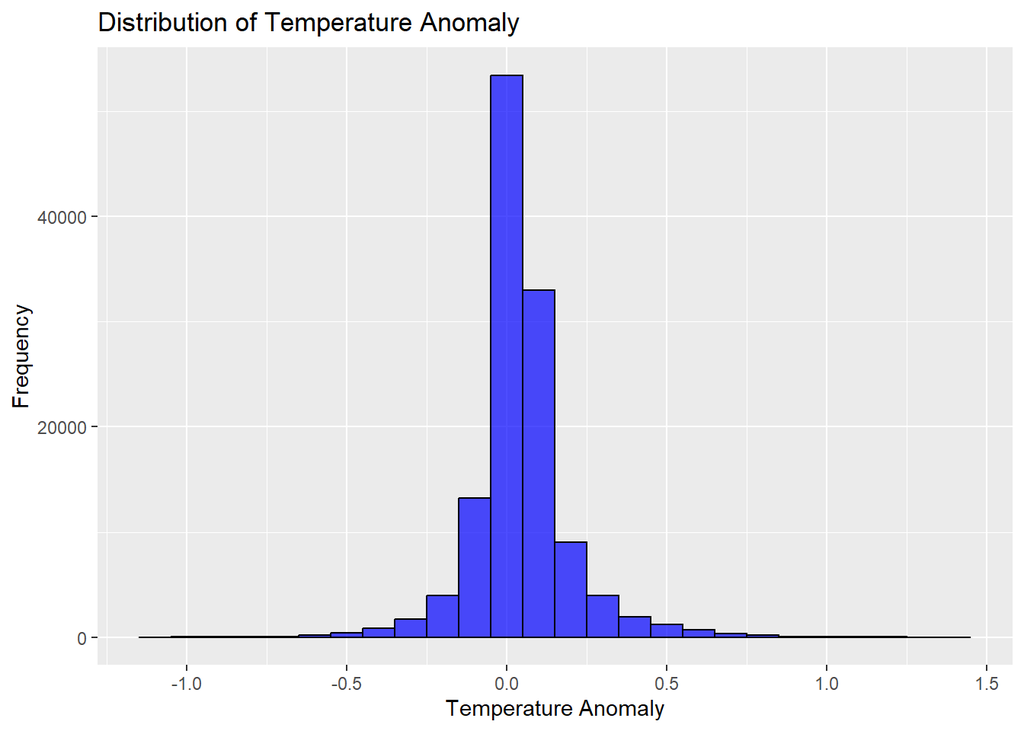

```r
ggplot(sample_df, aes(x = anomaly)) +
  geom_histogram(binwidth = 0.1, fill = "blue", color = "black", alpha = 0.7) +
  labs(title = "Distribution of Temperature Anomaly", x = "Temperature Anomaly", y = "Frequency")
```

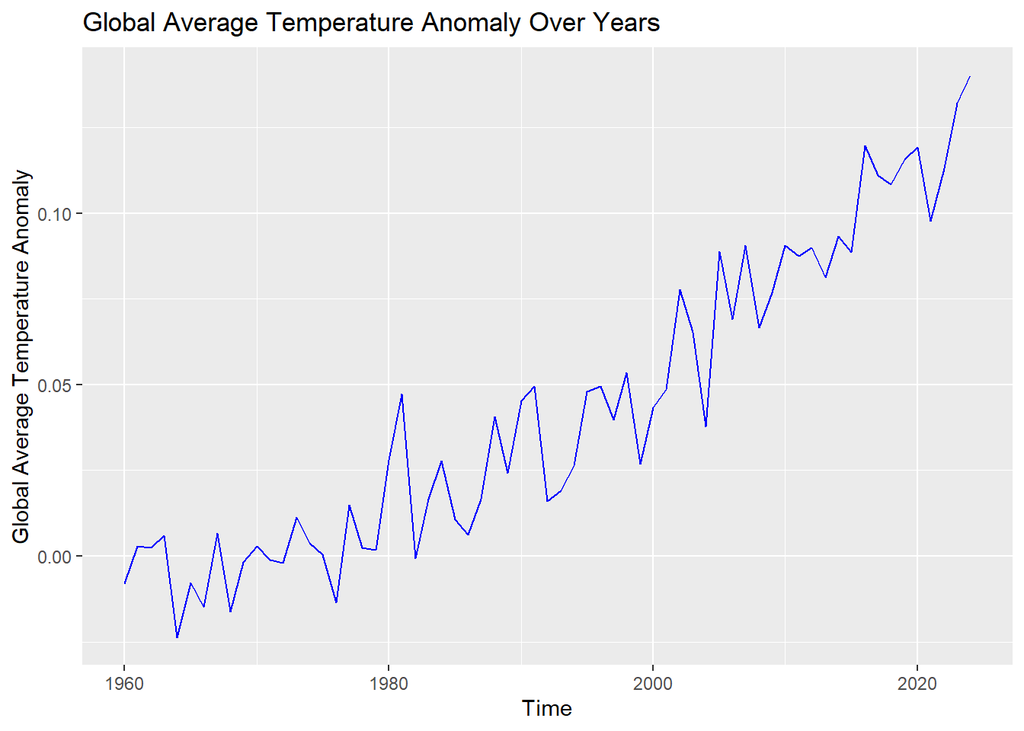

```r
sample_df <- sample_df %>% mutate(year = as.numeric(format(time, "%Y")))
yearly_data <- sample_df %>%
  group_by(year) %>%
  summarize(mean_temp_anomaly = mean(anomaly, na.rm = TRUE))

ggplot(yearly_data, aes(x = year, y = mean_temp_anomaly)) +
  geom_line(color = "blue") +
  labs(title = "Global Average Temperature Anomaly Over Years", x = "Time", y = "Global Average Temperature Anomaly")
```

## 1.2 Feature Engineering

### 1.2.1 Interpolation of missing data

A linear interpolation is performed to fill in the missing values in the `anomaly` column. We chose the linear interpolation method as it is a simple and effective way to estimate missing values in a time series dataset.

```r
# set the dataframe as a data.table to speed up feature engineering processes
setDT(df)

# Inspect rows with NA values
na_rows <- df[!complete.cases(df), ]
print(head(na_rows))
```

```
     lon   lat       time anomaly
   <num> <num>     <Date>   <num>
1:  -169   -69 1960-01-15      NA
2:  -167   -69 1960-01-15      NA
3:  -165   -69 1960-01-15      NA
4:  -163   -69 1960-01-15      NA
5:  -161   -69 1960-01-15      NA
6:  -159   -69 1960-01-15      NA
```

```r
# Create a copy of the original data before interpolation for comparison in the line graph
df_original <- df

# Impute missing values using linear interpolation
df$anomaly <- na.approx(df$anomaly, na.rm = FALSE)

any_na_interpolated <- any(is.na(df))
na_count_interpolated <- colSums(is.na(df))
cat("Number of NA values in each column after interpolation:")
```

```
Number of NA values in each column after interpolation:
```

```r
print(na_count_interpolated)
```

```
    lon     lat    time anomaly
      0       0       0       0
```

```r
cat("First few rows after interpolation:")
```

```
First few rows after interpolation:
```

```r
print(head(df))
```

```
     lon   lat       time anomaly
   <num> <num>     <Date>   <num>
1:  -179   -89 1960-01-15  -0.233
2:  -177   -89 1960-01-15  -0.233
3:  -175   -89 1960-01-15  -0.233
4:  -173   -89 1960-01-15  -0.233
5:  -171   -89 1960-01-15  -0.233
6:  -169   -89 1960-01-15  -0.233
```

```r
# Create a copy of the interpolated data for comparison in the line graph
df_interpolated <- df
```

### 1.2.2 Create column for Mean Temp anomaly for each year

We create a new column, `mean_anomaly`, to store the mean temperature anomaly for each year. This will help us to visualize the trend of temperature anomaly over the years.

```r
# Step 1: Extract the year from the date in the df data.table
df[, year := year(time)]

# Step 2 and Step 3: Group by year, lon, and lat, then calculate the mean temperature anomaly for each group
df_clean <- df[, .(mean_anomaly = mean(anomaly, na.rm = TRUE)), by = .(year, lon, lat)]

# Ensure the year column is of type character for plotly
df_clean[, year := as.character(year)]
```

### 1.2.3 Line Graph for comparison of temperature anomaly trend before and after interpolation

Here, we sample the interpolated `dataframe` again to **speed up** the process of plotting the line graph of before interpolation and after interpolation. This is to see if our interpolation was successful and does not introduce any new patterns.

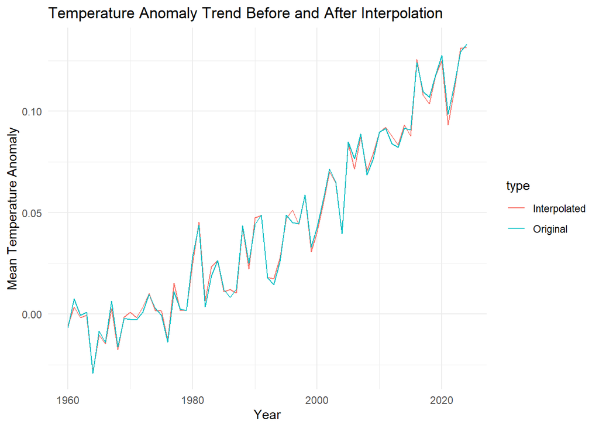

```r
# # sample 5% of data for faster plotting
df_original_sample <- df_original %>% sample_frac(0.05)
df_interpolated_sample <- df_interpolated %>% sample_frac(0.05)

# Add a column to identify the type of data
df_original_sample$type <- "Original"
df_interpolated_sample$type <- "Interpolated"

# Combine the original and interpolated data
df_combined <- bind_rows(df_original_sample, df_interpolated_sample)

# Ensure the combined dataframe has the same structure
df_combined <- df_combined |> select(lon, lat, time, anomaly, type)

# Summarize mean anomaly per year for both original and interpolated data
df_combined_summary <- df_combined |>
  mutate(year = as.numeric(format(time, "%Y"))) |>
  group_by(year, type) |>
  summarize(mean_anomaly = mean(anomaly, na.rm = TRUE), .groups = "drop")

# Create the line graph using ggplot2
ggplot(df_combined_summary, aes(x = year, y = mean_anomaly, color = type)) +
  geom_line() +
  labs(
    title = "Temperature Anomaly Trend Before and After Interpolation",
    x = "Year",
    y = "Mean Temperature Anomaly"
  ) +
  theme_minimal()
```

# 2. Data Visualization